# DATA 605 Final project

Samriti Malhotra

12/15/2019

# Computational Mathematics

Solutions should be provided in a format that can be shared on R Pubs and Git hub and You are also expected to make a short presentation via YouTube and post that recording to the board.

## Problem 1.

Using R, generate a random variable X that has 10,000 random uniform numbers from 1 to N, where N can be any number of your choosing greater than or equal to 6. Then generate a random variable Y that has 10,000 random normal numbers with a mean of N(N+1)/2.

Answer:

Generate a random variable X

```r
# set seed value
set.seed(1)
N <- 6
X <- runif(10000, min = 1, max = N)
```

Generate a random variable Y

```r
# mean
mu <- (N+1)/2
Y <- rnorm(10000 , mean = mu)
```

Probability. Calculate as a minimum the below probabilities a through c. Assume the small letter “x” is estimated as the median of the X variable, and the small letter “y” is estimated as the 1st quartile of the Y variable. Interpret the meaning of all probabilities.

### 5 points

#### a. P(X>x | X>y) = 0.7875256

Answer:

```r
# first calculate x and y
x <- median(X)
y <- summary(Y)[2][[1]]


#p(A|B) = P(AB)/P(B)
sum(X>x & X > y)/sum(X>y)
```

```
## [1] 0.7875256
```

The probability of X greater than median value of X given that X is greater than first quartile of y is 0.78.

#### b. P(X>x, Y>y) = 0.3754

Answer:

```r
#P(AB)
pab <- sum(X>x & Y>y)/length(X)
```

The probability of X greater than median value of X and Y is greater than first quartile of y is 0.3754.

#### c. P(X<x | X>y) = 0.2124744

Answer:

```r
#p(A|B) = P(AB)/P(B)
sum(X<x & X > y)/sum(X>y)
```

```
## [1] 0.2124744
```

The probability of X less than median value of X given that X is greater than first quartile of y is 0.2124744.

### 5 points. Investigate whether P(X>x and Y>y)=P(X>x)P(Y>y) by building a table and evaluating the marginal and joint probabilities.

Answer:

```r
tab <- c(sum(X<x & Y < y),
       sum(X < x & Y == y),
       sum(X < x & Y > y))
tab <- rbind(tab,
              c(sum(X==x & Y < y),
       sum(X == x & Y == y),
       sum(X == x & Y > y))

             )
tab <- rbind(tab,
              c(sum(X>x & Y < y),
       sum(X > x & Y == y),
       sum(X > x & Y > y))
             )
tab <- cbind(tab, tab[,1] + tab[,2] + tab[,3])
tab <- rbind(tab, tab[1,] + tab[2,] + tab[3,])
colnames(tab) <- c("Y<y", "Y=y", "Y>y", "Total")
rownames(tab) <- c("X<x", "X=x", "X>x", "Total")
knitr::kable(tab)
```

|  | Y<y | Y=y | Y>y | Total |
| --- | --- | --- | --- | --- |
| X<x | 1254 | 0 | 3746 | 5000 |
| X=x | 0 | 0 | 0 | 0 |
| X>x | 1246 | 0 | 3754 | 5000 |
| Total | 2500 | 0 | 7500 | 10000 |

We’ve made joint and marginal probability table. Now we’ll test the condition

```r
# P(X>x and Y>y)
3754/10000
```

```
## [1] 0.3754
```

```r
#P(X>x)P(Y>y)
((5000)/10000)*(7500/10000)
```

```
## [1] 0.375
```

we can see that the condition holds since P(X>x and Y>y) = 0.3754 and P(X>x)P(Y>y) = 0.375 are approximately equal.

### 5 points. Check to see if independence holds by using Fisher’s Exact Test and the Chi Square Test. What is the difference between the two? Which is most appropriate?

Answer:

Fisher’s Exact Test

```r
fisher.test(table(X>x,Y>y))
```

```
##
##  Fisher's Exact Test for Count Data
##
## data:  table(X > x, Y > y)
## p-value = 0.8716
## alternative hypothesis: true odds ratio is not equal to 1
## 95 percent confidence interval:
##  0.9202847 1.1052820
## sample estimates:
## odds ratio
##    1.00857
```

The p-value is greater than zero we don’t reject the null hypothesis. Two events are independent.

The Chi Square Test

```r
chisq.test(table(X>x,Y>y))
```

```
##
##  Pearson's Chi-squared test with Yates' continuity correction
##
## data:  table(X > x, Y > y)
## X-squared = 0.026133, df = 1, p-value = 0.8716
```

The p-value is greeter than zero we don’t reject the null hypothesis. Two events are independent.

Fisher’s exact test the null of independence of rows and columns in a contingency table with fixed marginals.

Chi-squared test tests contingency table tests and goodness-of-fit tests.

Fisher’s exact test is appropriate here. Since the contingency table are fixed here in the table.

## Problem 2

You are to register for Kaggle.com (free) and compete in the House Prices: Advanced Regression Techniques competition. https://www.kaggle.com/c/house-prices-advanced-regression-techniques . I want you to do the following.

Load the libraries

```r
library(readr)
library(tidyverse)
```

Read the data

```r
train <- read_csv("train.csv")
test <- read_csv("test.csv")
```

### 5 points. Descriptive and Inferential Statistics.

Provide univariate descriptive statistics and appropriate plots for the training data set.

Provide a scatter-plot matrix for at least two of the independent variables and the dependent variable.

Derive a correlation matrix for any three quantitative variables in the data-set.

Discuss the meaning of your analysis. Would you be worried about family-wise error? Why or why not?

#### uni-variate descriptive statistics

```r
summary(train)
```

```
##        Id           MSSubClass      MSZoning          LotFrontage
##  Min.   :   1.0   Min.   : 20.0   Length:1460        Min.   : 21.00
##  1st Qu.: 365.8   1st Qu.: 20.0   Class :character   1st Qu.: 59.00
##  Median : 730.5   Median : 50.0   Mode  :character   Median : 69.00
##  Mean   : 730.5   Mean   : 56.9                      Mean   : 70.05
##  3rd Qu.:1095.2   3rd Qu.: 70.0                      3rd Qu.: 80.00
##  Max.   :1460.0   Max.   :190.0                      Max.   :313.00
##                                                      NA's   :259
##     LotArea          Street             Alley             LotShape
##  Min.   :  1300   Length:1460        Length:1460        Length:1460
##  1st Qu.:  7554   Class :character   Class :character   Class :character
##  Median :  9478   Mode  :character   Mode  :character   Mode  :character
##  Mean   : 10517
##  3rd Qu.: 11602
##  Max.   :215245
##
##  LandContour         Utilities          LotConfig
##  Length:1460        Length:1460        Length:1460
##  Class :character   Class :character   Class :character
##  Mode  :character   Mode  :character   Mode  :character
##
##
##
##
##   LandSlope         Neighborhood        Condition1
##  Length:1460        Length:1460        Length:1460
##  Class :character   Class :character   Class :character
##  Mode  :character   Mode  :character   Mode  :character
##
##
##
##
##   Condition2          BldgType          HouseStyle         OverallQual
##  Length:1460        Length:1460        Length:1460        Min.   : 1.000
##  Class :character   Class :character   Class :character   1st Qu.: 5.000
##  Mode  :character   Mode  :character   Mode  :character   Median : 6.000
##                                                           Mean   : 6.099
##                                                           3rd Qu.: 7.000
##                                                           Max.   :10.000
##
```

[output cut: 121 more lines]

```
##  Min.   :    0.00   Min.   : 1.000   Min.   :2006   Length:1460
##  1st Qu.:    0.00   1st Qu.: 5.000   1st Qu.:2007   Class :character
##  Median :    0.00   Median : 6.000   Median :2008   Mode  :character
##  Mean   :   43.49   Mean   : 6.322   Mean   :2008
##  3rd Qu.:    0.00   3rd Qu.: 8.000   3rd Qu.:2009
##  Max.   :15500.00   Max.   :12.000   Max.   :2010
##
##  SaleCondition        SalePrice
##  Length:1460        Min.   : 34900
##  Class :character   1st Qu.:129975
##  Mode  :character   Median :163000
##                     Mean   :180921
##                     3rd Qu.:214000
##                     Max.   :755000
##
```

#### Plots

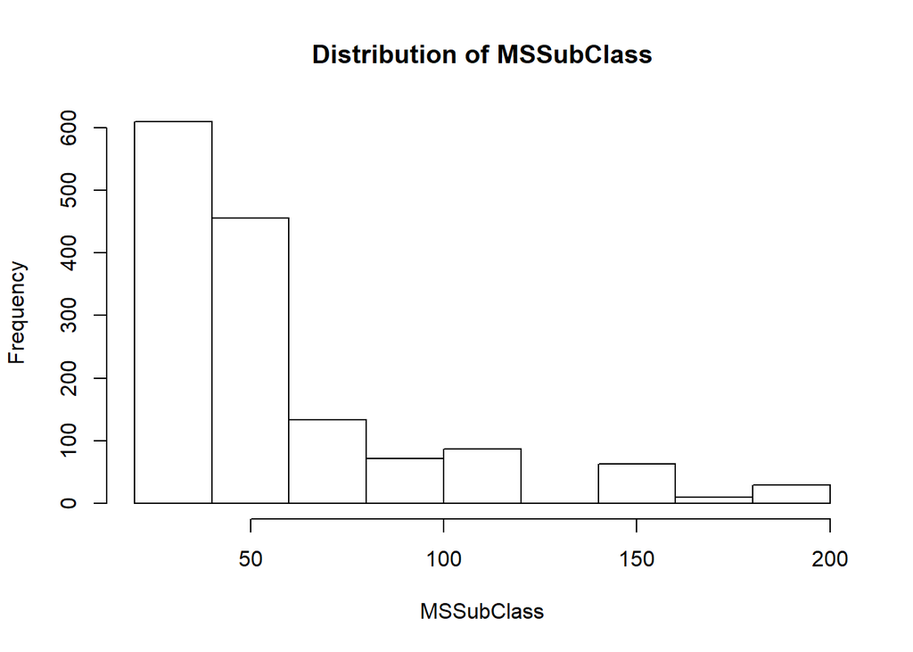

```r
hist(train$MSSubClass, main="Distribution of MSSubClass",xlab="MSSubClass")
```

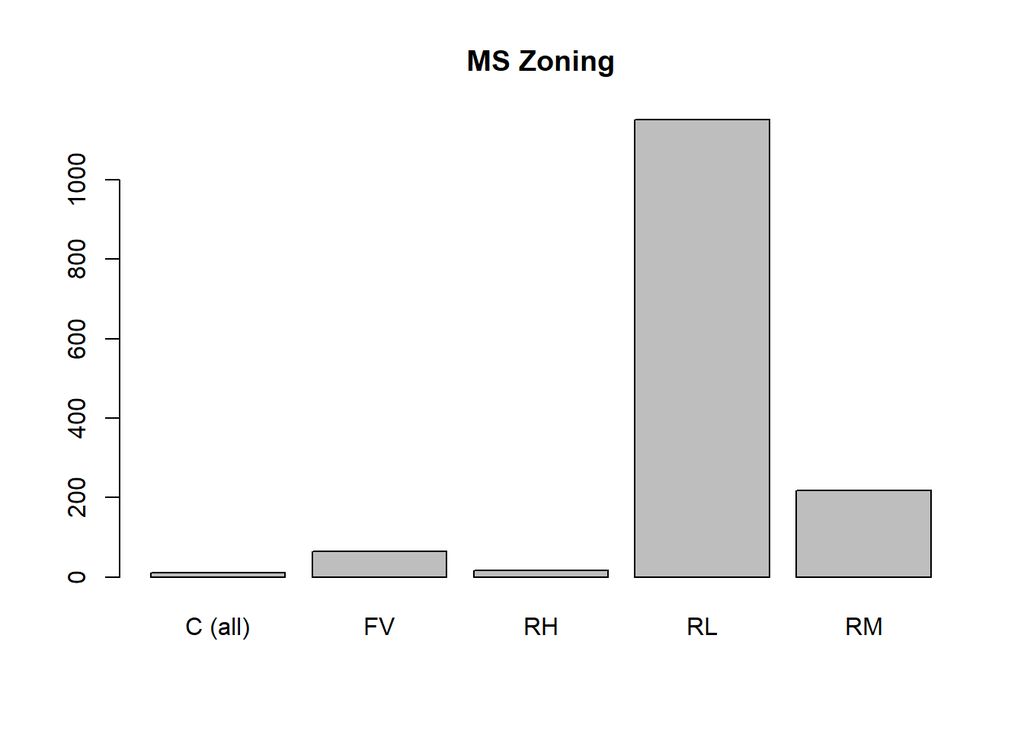

```r
barplot(table(train$MSZoning), main="MS Zoning")
```

RL has the highest frequency , C lowest frequency.

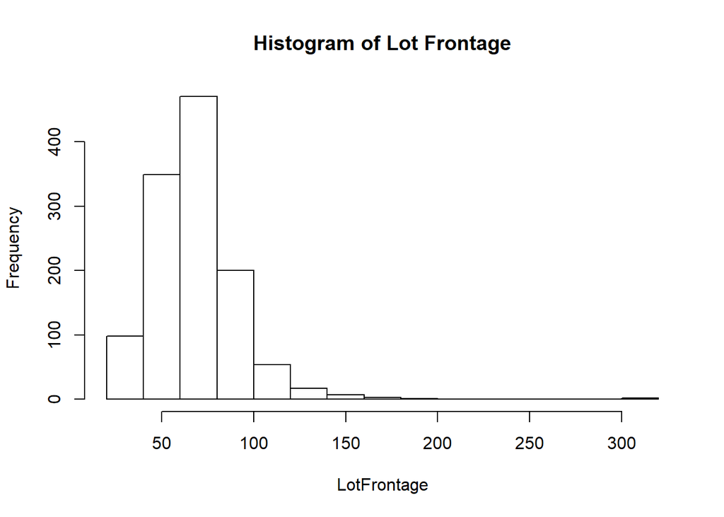

```r
hist(train$LotFrontage,main="Histogram of Lot Frontage",xlab="LotFrontage")
```

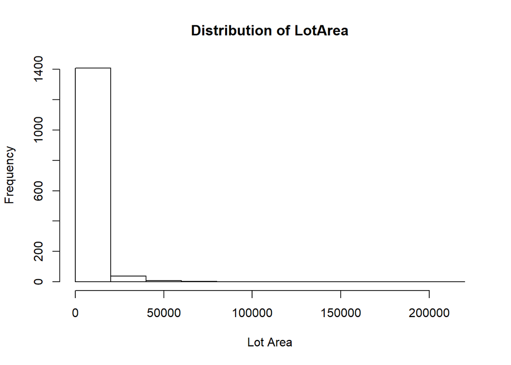

```r
hist(train$LotArea,main="Distribution of LotArea",xlab="Lot Area")
```

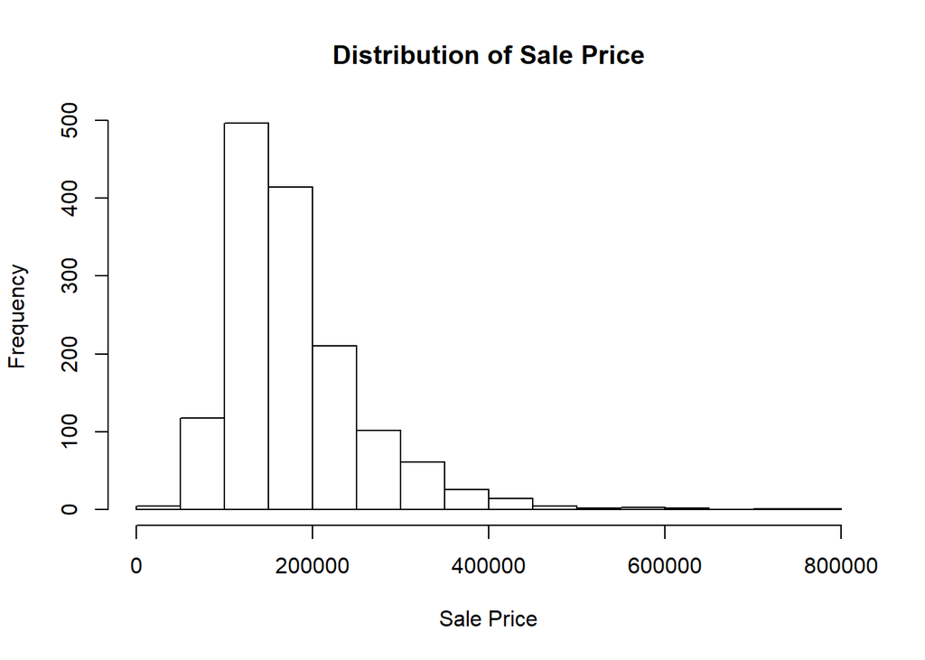

```r
hist(train$SalePrice,main="Distribution of Sale Price",xlab="Sale Price")
```

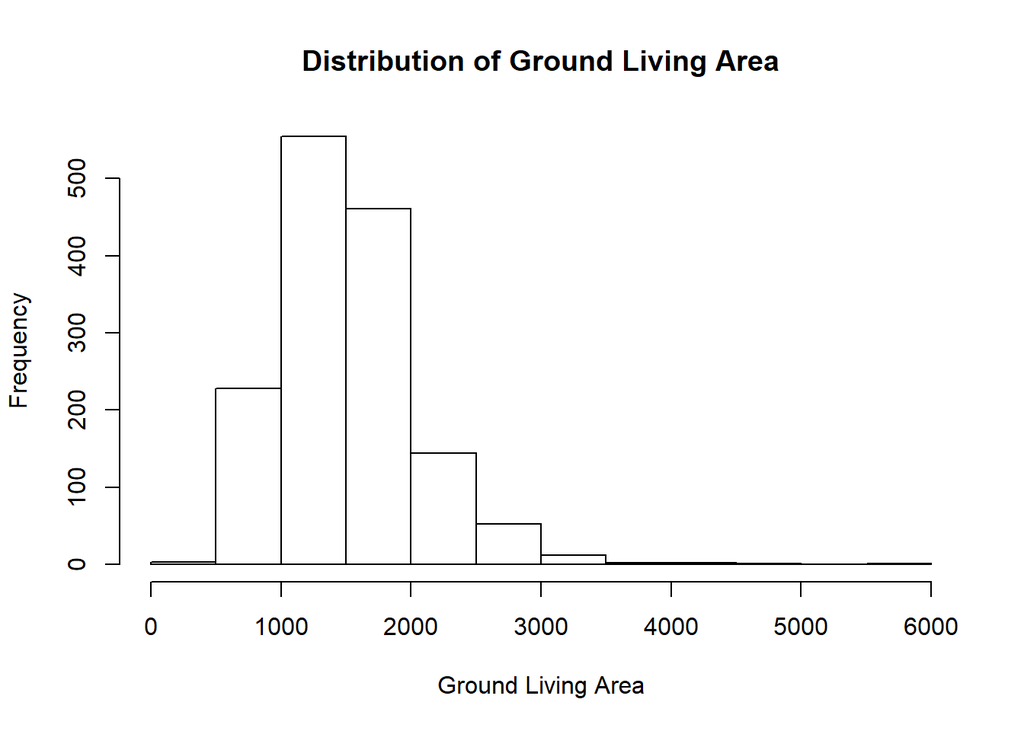

```r
hist(train$GrLivArea,main="Distribution of Ground Living Area",xlab="Ground Living Area")
```

#### Scatterplot matrix for “SalePrice”,“GrLivArea”,“LotFrontage”

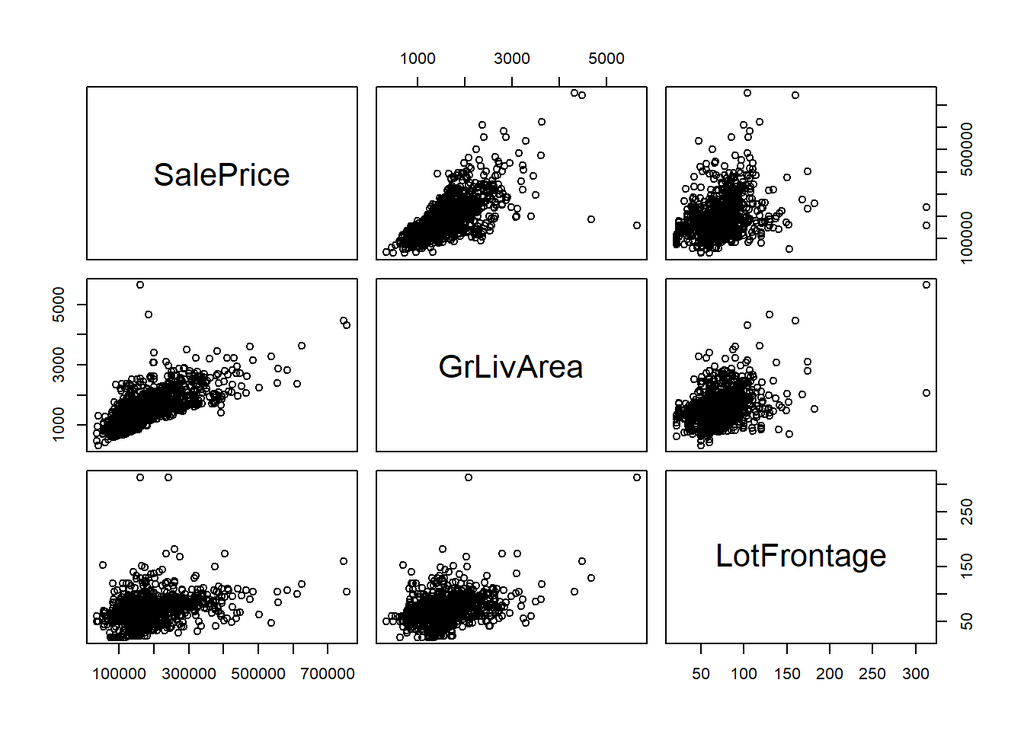

```r
pairs(train[,c("SalePrice","GrLivArea","LotFrontage")])
```

From the scatter plot we can see that GrLiveArea and LotFrontage are positively correlated with Sale Price.

#### Correlation matrix for any three quantitative variables

SalePrice , GrLivArea and TotalBsmtSF

```r
cormat <- cor(train[,c("SalePrice","GrLivArea","TotalBsmtSF")])
cormat
```

```
##             SalePrice GrLivArea TotalBsmtSF
## SalePrice   1.0000000 0.7086245   0.6135806
## GrLivArea   0.7086245 1.0000000   0.4548682
## TotalBsmtSF 0.6135806 0.4548682   1.0000000
```

SalePrice shows strong positive correlation with GrLivArea and moderate correlation with TotalBsmTSF.

GrLivArea shows Strong positive correlation with SalePrice and weak positive correlation with TotalBsmSF.

TotalBsmSF shows moderate positive correlation with SalePrice and weak positive correlation with GrLivArea.

Test the hypotheses that the correlations between each pairwise set of variables is 0 and provide an 80% confidence interval.  
SalePrice vs GrLivArea

Null Hypothesis: The correlation between GrLivArea and SalePrice is 0 Alternative Hypothesis: The correlation between GrLivArea and SalePrice is other than 0

```r
cor.test(train$SalePrice, train$GrLivArea, conf.level = 0.8)
```

```
##
##  Pearson's product-moment correlation
##
## data:  train$SalePrice and train$GrLivArea
## t = 38.348, df = 1458, p-value < 0.00000000000000022
## alternative hypothesis: true correlation is not equal to 0
## 80 percent confidence interval:
##  0.6915087 0.7249450
## sample estimates:
##       cor
## 0.7086245
```

Null Hypothesis: The correlation between TotalBsmtSF and SalePrice is 0 Alternative Hypothesis: The correlation between TotalBsmtSF and SalePrice is other than 0

```r
cor.test(train$SalePrice, train$TotalBsmtSF, conf.level = 0.8)
```

```
##
##  Pearson's product-moment correlation
##
## data:  train$SalePrice and train$TotalBsmtSF
## t = 29.671, df = 1458, p-value < 0.00000000000000022
## alternative hypothesis: true correlation is not equal to 0
## 80 percent confidence interval:
##  0.5922142 0.6340846
## sample estimates:
##       cor
## 0.6135806
```

Since the the p value of the test is less than 0.05 at 5% level of significance we reject the null hypothesis and conclude that the correlation between TotalBsmtSF and SalePrice is other than 0.

Null Hypothesis: The correlation between TotalBsmtSF and GrLivArea is 0 Alternative Hypothesis: The correlation between TotalBsmtSF and GrLivArea is other than 0

```r
cor.test(train$GrLivArea, train$TotalBsmtSF, conf.level = 0.8)
```

```
##
##  Pearson's product-moment correlation
##
## data:  train$GrLivArea and train$TotalBsmtSF
## t = 19.503, df = 1458, p-value < 0.00000000000000022
## alternative hypothesis: true correlation is not equal to 0
## 80 percent confidence interval:
##  0.4278380 0.4810855
## sample estimates:
##       cor
## 0.4548682
```

Since the the p value of the test is less than 0.05 at 5% level of significance we reject the null hypothesis and conclude that the correlation between GrLivArea and TotalBsmtSF is other than 0.

#### family wise error

```r
FWE <- 1 - (1 - .05)^2
FWE
```

```
## [1] 0.0975
```

There is a 9.75% chance of type 1 error. Since the chance is low I will not be worried for family wise error .

### 5 points. Linear Algebra and Correlation. Invert your correlation matrix from above. (This is known as the precision matrix and contains variance inflation factors on the diagonal.) Multiply the correlation matrix by the precision matrix, and then multiply the precision matrix by the correlation matrix. Conduct LU decomposition on the matrix.

Answer:

```r
# find inverse
precision_mat <- solve(cormat)

# Multiply the correlation matrix by the precision matrix
cor_prec <- cormat %*% precision_mat
cor_prec
```

```
##                             SalePrice                  GrLivArea
## SalePrice   1.00000000000000022204460 -0.00000000000000002081668
## GrLivArea   0.00000000000000005551115  1.00000000000000000000000
## TotalBsmtSF 0.00000000000000000000000  0.00000000000000005551115
##                          TotalBsmtSF
## SalePrice   0.0000000000000000000000
## GrLivArea   0.0000000000000001110223
## TotalBsmtSF 1.0000000000000000000000
```

```r
#  multiply the precision matrix by the correlation matrix
prec_cor <-   precision_mat %*% cormat
prec_cor
```

```
##                            SalePrice                 GrLivArea
## SalePrice   0.9999999999999997779554 -0.0000000000000001665335
## GrLivArea   0.0000000000000002012279  1.0000000000000004440892
## TotalBsmtSF 0.0000000000000000000000  0.0000000000000001110223
##                           TotalBsmtSF
## SalePrice   -0.0000000000000001110223
## GrLivArea    0.0000000000000001665335
## TotalBsmtSF  1.0000000000000000000000
```

```r
# LU Decomposistion
library(pracma)
lu(cormat)
```

```
## $L
##             SalePrice  GrLivArea TotalBsmtSF
## SalePrice   1.0000000 0.00000000           0
## GrLivArea   0.7086245 1.00000000           0
## TotalBsmtSF 0.6135806 0.04031325           1
##
## $U
##             SalePrice GrLivArea TotalBsmtSF
## SalePrice           1 0.7086245   0.6135806
## GrLivArea           0 0.4978513   0.0200700
## TotalBsmtSF         0 0.0000000   0.6227098
```

#### 5 points. Calculus-Based Probability & Statistics. Many times, it makes sense to fit a closed form distribution to data. Select a variable in the Kaggle.com training dataset that is skewed to the right, shift it so that the minimum value is absolutely above zero if necessary. Then load the MASS package and run fitdistr to fit an exponential probability density function. (See https://stat.ethz.ch/R-manual/R-devel/library/MASS/html/fitdistr.html ).

Find the optimal value of  for this distribution, and then take 1000 samples from this exponential distribution using this value (e.g., rexp(1000, )). Plot a histogram and compare it with a histogram of your original variable.

Using the exponential pdf, find the 5th and 95th percentiles using the cumulative distribution function (CDF).

Also generate a 95% confidence interval from the empirical data, assuming normality.

Answer: We select LotArea as it’s skewed to the right.

#### optimal value of exponential for this distribution

```r
library(MASS)
# Fitting of univariate distribution
(fd <- fitdistr(train$LotArea, "exponential"))
```

```
##         rate
##   0.000095085704
##  (0.000002488507)
```

```r
# optimam value of lambda
fd$estimate
```

```
##         rate
## 0.0000950857
```

#### 1000 samples from this exponential distribution using this value

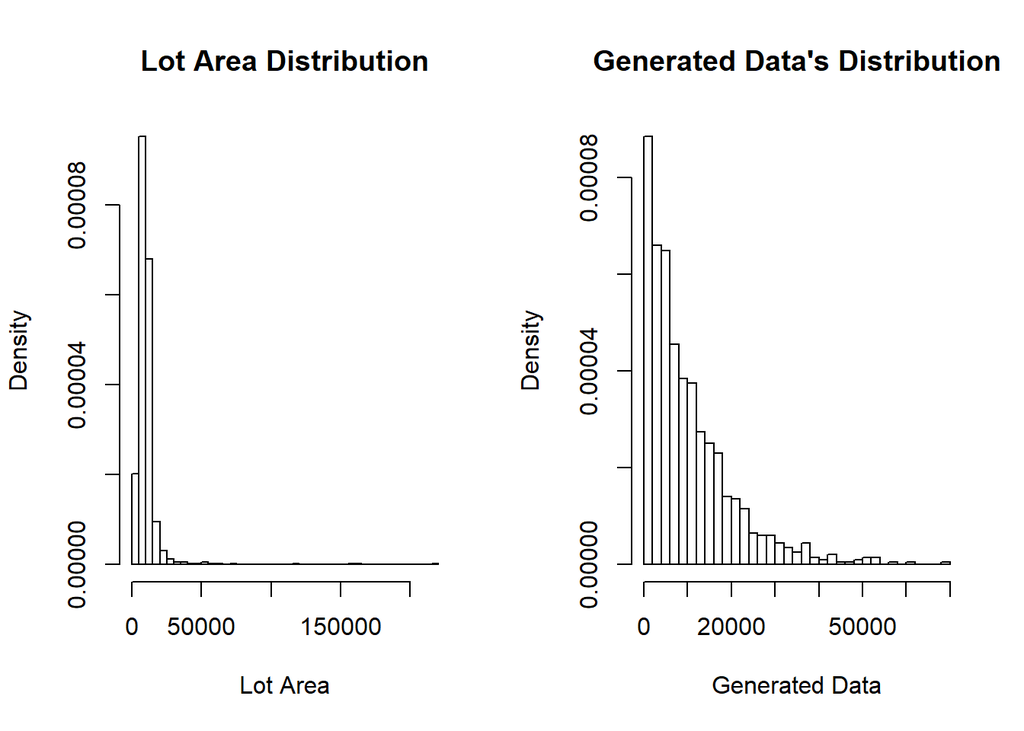

```r
values <- rexp(1000, rate = fd$estimate)
par(mfrow=c(1,2))
# Actual vs simulated distribution
hist(train$LotArea, breaks=40, prob=TRUE, xlab="Lot Area",
     main="Lot Area Distribution")
hist(values, breaks=40, prob=TRUE, xlab="Generated Data",
     main="Generated Data's Distribution")
```

From the two plots we can see that our Lot Area approximately fits a exponential distribution. The fit isn’t very well here.

#### 5th and 95th percentiles using the cumulative distribution function (CDF)

```r
Fn <- ecdf(values)
values[Fn(values)==0.05]
```

```
## [1] 402.4144
```

```r
values[Fn(values)==0.95]
```

```
## [1] 30176.06
```

#### 95% confidence interval from the empirical data

```r
t.test(values)$conf.int
```

```
## [1]  9667.527 10915.180
## attr(,"conf.level")
## [1] 0.95
```

```r
t.test(train$LotArea)$conf.int
```

```
## [1] 10004.42 11029.24
## attr(,"conf.level")
## [1] 0.95
```

### 10 points. Modeling. Build some type of multiple regression model and submit your model to the competition board. Provide your complete model summary and results with analysis. Report your Kaggle.com user name and score.

Answer:

#### Model Summary:

For building model I’ve removed the variables with very large number of missing values. Then recoded the categorical variables to numerical variable. After that I’ve fitted a multiple regression model. After fitting the multiple regression model I’ve used step wise regression to select best set of predictor variables.

#### We’ll see number of missing values in the variables

```r
sapply(train, function(x){sum(is.na(x))})
```

```
##            Id    MSSubClass      MSZoning   LotFrontage       LotArea
##             0             0             0           259             0
##        Street         Alley      LotShape   LandContour     Utilities
##             0          1369             0             0             0
##     LotConfig     LandSlope  Neighborhood    Condition1    Condition2
##             0             0             0             0             0
##      BldgType    HouseStyle   OverallQual   OverallCond     YearBuilt
##             0             0             0             0             0
##  YearRemodAdd     RoofStyle      RoofMatl   Exterior1st   Exterior2nd
##             0             0             0             0             0
##    MasVnrType    MasVnrArea     ExterQual     ExterCond    Foundation
##             8             8             0             0             0
##      BsmtQual      BsmtCond  BsmtExposure  BsmtFinType1    BsmtFinSF1
##            37            37            38            37             0
##  BsmtFinType2    BsmtFinSF2     BsmtUnfSF   TotalBsmtSF       Heating
##            38             0             0             0             0
##     HeatingQC    CentralAir    Electrical      1stFlrSF      2ndFlrSF
##             0             0             1             0             0
##  LowQualFinSF     GrLivArea  BsmtFullBath  BsmtHalfBath      FullBath
##             0             0             0             0             0
##      HalfBath  BedroomAbvGr  KitchenAbvGr   KitchenQual  TotRmsAbvGrd
##             0             0             0             0             0
##    Functional    Fireplaces   FireplaceQu    GarageType   GarageYrBlt
##             0             0           690            81            81
##  GarageFinish    GarageCars    GarageArea    GarageQual    GarageCond
##            81             0             0            81            81
##    PavedDrive    WoodDeckSF   OpenPorchSF EnclosedPorch     3SsnPorch
##             0             0             0             0             0
##   ScreenPorch      PoolArea        PoolQC         Fence   MiscFeature
##             0             0          1453          1179          1406
##       MiscVal        MoSold        YrSold      SaleType SaleCondition
##             0             0             0             0             0
##     SalePrice
##             0
```

We’ll remove variables having a large number of missing values. we’ll also remove irremovable,YearBuilt

```r
train <-train[, !colnames(train) %in% c("Id","Alley","PoolQC","Fence","MiscFeature","FireplaceQu","LotFrontage","YearBuilt","YearRemodAdd")]

test <- test[, !colnames(test) %in% c("Alley","PoolQC","Fence","MiscFeature","FireplaceQu","LotFrontage","YearBuilt","YearRemodAdd")]

# convert categorical to numeric

train <- train%>%
  mutate_if(is.character, as.factor)%>%
  mutate_if(is.factor, as.integer)

test <- test %>%
   mutate_if(is.character, as.factor)%>%
  mutate_if(is.factor, as.integer)
```

Now we’ll take only complete cases

```r
train <- na.omit(train)
```

#### We’ll not fit a multiple regression model

```r
model_fit <- lm(SalePrice~., data = train)
summary(model_fit)
```

```
##
## Call:
## lm(formula = SalePrice ~ ., data = train)
##
## Residuals:
##     Min      1Q  Median      3Q     Max
## -434183  -13770    -848   12990  292689
##
## Coefficients: (2 not defined because of singularities)
##                    Estimate    Std. Error t value             Pr(>|t|)
## (Intercept)   2169226.04952 1405502.84800   1.543             0.122988
## MSSubClass       -151.76908      50.65553  -2.996             0.002788 **
## MSZoning        -2016.34133    1642.98609  -1.227             0.219959
## LotArea             0.37915       0.11051   3.431             0.000621 ***
## Street          37981.07458   16087.18883   2.361             0.018379 *
## LotShape        -1327.90285     698.94808  -1.900             0.057678 .
## LandContour      4069.04766    1487.17385   2.736             0.006304 **
## Utilities      -50137.11987   34166.29186  -1.467             0.142503
## LotConfig         169.82021     577.93533   0.294             0.768929
## LandSlope        5837.59431    4148.29648   1.407             0.159605
## Neighborhood      212.15266     169.02832   1.255             0.209663
## Condition1       -518.49429    1065.63381  -0.487             0.626655
## Condition2      -7975.19606    3451.46842  -2.311             0.021011 *
## BldgType         -251.46567    1595.80939  -0.158             0.874814
## HouseStyle       -913.21759     691.12993  -1.321             0.186626
## OverallQual     12660.37979    1291.66460   9.802 < 0.0000000000000002 ***
## OverallCond      4053.20893    1037.82540   3.905       0.000098993057 ***
## RoofStyle        2449.61702    1196.33409   2.048             0.040805 *
## RoofMatl         4248.28868    1598.10003   2.658             0.007952 **
## Exterior1st      -945.09263     570.40793  -1.657             0.097793 .
## Exterior2nd       310.63359     511.62505   0.607             0.543860
## MasVnrType       4267.07351    1640.62044   2.601             0.009406 **
## MasVnrArea         30.06517       6.34084   4.742       0.000002361198 ***
## ExterQual       -8571.34766    2120.40336  -4.042       0.000056111669 ***
## ExterCond         597.64250    1417.80253   0.422             0.673442
## Foundation       2878.41233    1843.28975   1.562             0.118641
## BsmtQual        -8897.77673    1528.18705  -5.822       0.000000007341 ***
## BsmtCond         2973.00730    1486.52840   2.000             0.045717 *
## BsmtExposure    -3659.85244     936.09504  -3.910       0.000097300199 ***
## BsmtFinType1    -1130.83469     677.53469  -1.669             0.095356 .
```

[output cut: 33 more lines]

```
## EnclosedPorch      -6.42617      16.35079  -0.393             0.694372
## `3SsnPorch`        22.97673      30.16114   0.762             0.446322
## ScreenPorch        43.64636      16.46591   2.651             0.008132 **
## PoolArea          -26.16388      22.58834  -1.158             0.246963
## MiscVal             0.04267       1.81403   0.024             0.981235
## MoSold           -155.06018     342.01553  -0.453             0.650359
## YrSold          -1044.20540     696.10119  -1.500             0.133843
## SaleType         -526.77360     605.10830  -0.871             0.384168
## SaleCondition    2684.26064     921.03004   2.914             0.003626 **
## ---
## Signif. codes:  0 '***' 0.001 '**' 0.01 '*' 0.05 '.' 0.1 ' ' 1
##
## Residual standard error: 32460 on 1268 degrees of freedom
## Multiple R-squared:  0.8396, Adjusted R-squared:  0.8308
## F-statistic: 96.17 on 69 and 1268 DF,  p-value: < 0.00000000000000022
```

#### We’ll now do a stepwise regression based on ACI criterion

```r
step_model <- step(model_fit, trace = 0)
summary(step_model)
```

```
##
## Call:
## lm(formula = SalePrice ~ MSSubClass + MSZoning + LotArea + Street +
##     LotShape + LandContour + LandSlope + Condition2 + HouseStyle +
##     OverallQual + OverallCond + RoofStyle + RoofMatl + Exterior1st +
##     MasVnrType + MasVnrArea + ExterQual + Foundation + BsmtQual +
##     BsmtCond + BsmtExposure + BsmtFinType1 + BsmtFinSF1 + `1stFlrSF` +
##     `2ndFlrSF` + BsmtFullBath + FullBath + BedroomAbvGr + KitchenAbvGr +
##     KitchenQual + TotRmsAbvGrd + Functional + Fireplaces + GarageCars +
##     PavedDrive + WoodDeckSF + ScreenPorch + SaleCondition, data = train)
##
## Residuals:
##     Min      1Q  Median      3Q     Max
## -441172  -13550    -957   13442  278991
##
## Coefficients:
##                  Estimate  Std. Error t value             Pr(>|t|)
## (Intercept)   -68655.8503  38693.5272  -1.774             0.076239 .
## MSSubClass      -159.8789     27.4961  -5.815    0.000000007641103 ***
## MSZoning       -2503.0986   1534.7315  -1.631             0.103139
## LotArea            0.3814      0.1060   3.597             0.000333 ***
## Street         40806.0476  15627.6939   2.611             0.009128 **
## LotShape       -1310.5266    669.9525  -1.956             0.050662 .
## LandContour     3914.9209   1436.8188   2.725             0.006522 **
## LandSlope       6115.5394   4036.2642   1.515             0.129978
## Condition2     -7336.6650   3325.0186  -2.207             0.027523 *
## HouseStyle     -1224.6140    616.7163  -1.986             0.047277 *
## OverallQual    12959.5731   1248.8115  10.378 < 0.0000000000000002 ***
## OverallCond     4247.8548    928.1763   4.577    0.000005179174355 ***
## RoofStyle       2632.4405   1158.2961   2.273             0.023208 *
## RoofMatl        4131.9524   1555.7715   2.656             0.008007 **
## Exterior1st     -614.3119    301.9824  -2.034             0.042128 *
## MasVnrType      4335.1776   1582.5650   2.739             0.006241 **
## MasVnrArea        30.2912      6.1226   4.947    0.000000850306146 ***
## ExterQual      -8542.1790   2043.1130  -4.181    0.000030972233573 ***
## Foundation      3189.2880   1670.1013   1.910             0.056400 .
## BsmtQual       -8946.3960   1491.0981  -6.000    0.000000002557006 ***
## BsmtCond        3202.5638   1404.1962   2.281             0.022727 *
## BsmtExposure   -3678.7800    901.4594  -4.081    0.000047592852072 ***
## BsmtFinType1   -1168.7326    649.9609  -1.798             0.072384 .
## BsmtFinSF1         5.8341      3.1549   1.849             0.064652 .
## `1stFlrSF`        45.5519      4.8433   9.405 < 0.0000000000000002 ***
## `2ndFlrSF`        45.2873      4.1751  10.847 < 0.0000000000000002 ***
## BsmtFullBath    7523.9163   2355.1435   3.195             0.001434 **
## FullBath        4197.5166   2518.4225   1.667             0.095810 .
## BedroomAbvGr   -4439.2566   1771.3141  -2.506             0.012325 *
## KitchenAbvGr  -21663.3923   6032.6496  -3.591             0.000342 ***
## KitchenQual    -8746.4950   1523.4941  -5.741    0.000000011699055 ***
## TotRmsAbvGrd    3456.5692   1200.5186   2.879             0.004052 **
## Functional      3843.4812   1016.0138   3.783             0.000162 ***
## Fireplaces      4035.7108   1688.6046   2.390             0.016992 *
## GarageCars     14425.7154   1972.8288   7.312    0.000000000000458 ***
## PavedDrive      4949.3592   2348.8421   2.107             0.035296 *
## WoodDeckSF        18.4401      7.5978   2.427             0.015359 *
## ScreenPorch       41.4813     15.9000   2.609             0.009188 **
## SaleCondition   2596.0989    873.9699   2.970             0.003028 **
## ---
## Signif. codes:  0 '***' 0.001 '**' 0.01 '*' 0.05 '.' 0.1 ' ' 1
##
## Residual standard error: 32290 on 1299 degrees of freedom
## Multiple R-squared:  0.8373, Adjusted R-squared:  0.8326
## F-statistic:   176 on 38 and 1299 DF,  p-value: < 0.00000000000000022
```

#### Our Final model

R squared values 0.8373 indicates that our model is a very good model. Our fitted multiple regression model is 83.73% accurate in predicting Sales price based on the dependent variables. Since the F tests p value less than 0.05 at 5% level of significance our model is a valid model.

#### Residual Analysis

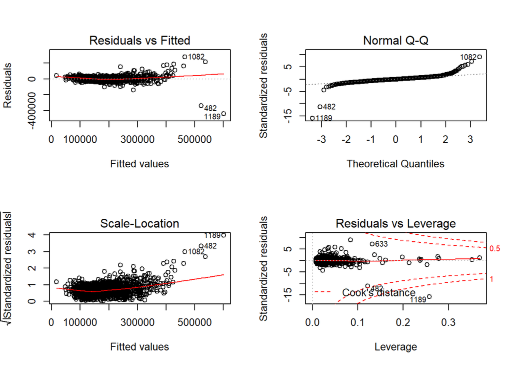

```r
par(mfrow=c(2,2))
plot(step_model)
```

```r
predicted <- predict(step_model, test)
sub <- data.frame(Id = test$Id, SalePrice=predicted)
write.csv(sub,"submission.csv",row.names = FALSE)
```

#### Kaggle Submission

Kaggle username is **simi0202** . Final score is **0.46708**.